# Project: Creating Customer Segments

In this project, I analyze a dataset containing data on various customers' annual spending amounts (reported in *monetary units*) of diverse product categories for internal structure. One goal of this project is to best describe the variation in the different types of customers that a wholesale distributor interacts with, and find costumer segments around which specific costumer groups can be found. Doing so would equip the distributor with insight into how to best structure their delivery service to meet the needs of each customer.

The dataset for this project can be found on the [UCI Machine Learning Repository](https://archive.ics.uci.edu/ml/datasets/Wholesale+customers). For the purposes of this project, the features `'Channel'` and `'Region'` will be excluded in the analysis — with focus instead on the six product categories recorded for customers.

```python
# Import libraries necessary for this project
import numpy as np
import pandas as pd
from IPython.display import display # Allows the use of display() for DataFrames

# Import supplementary visualizations code visuals.py
import visuals as vs

# Pretty display for notebooks
%matplotlib inline
import matplotlib as mpl
mpl.rcParams['figure.figsize'] = (14,8)

# Load the wholesale customers dataset
try:
    data = pd.read_csv("customers.csv")
    data.drop(['Region', 'Channel'], axis = 1, inplace = True)
    print("Wholesale customers dataset has {} samples with {} features each.".format(*data.shape))
except:
    print("Dataset could not be loaded. Is the dataset missing?")
```

```
Wholesale customers dataset has 440 samples with 6 features each.
```

## Data Exploration

This section is a basic exploration of the dataset to understand how each feature is related to the others and the relevance of each feature.

The dataset is composed of six important product categories: **'Fresh'**, **'Milk'**, **'Grocery'**, **'Frozen'**, **'Detergents_Paper'**, and **'Delicatessen'**.

```python
# Display a description of the dataset
display(data.describe())
```

|  | Fresh | Milk | Grocery | Frozen | Detergents_Paper | Delicatessen |
| --- | --- | --- | --- | --- | --- | --- |
| count | 440.000000 | 440.000000 | 440.000000 | 440.000000 | 440.000000 | 440.000000 |
| mean | 12000.297727 | 5796.265909 | 7951.277273 | 3071.931818 | 2881.493182 | 1524.870455 |
| std | 12647.328865 | 7380.377175 | 9503.162829 | 4854.673333 | 4767.854448 | 2820.105937 |
| min | 3.000000 | 55.000000 | 3.000000 | 25.000000 | 3.000000 | 3.000000 |
| 25% | 3127.750000 | 1533.000000 | 2153.000000 | 742.250000 | 256.750000 | 408.250000 |
| 50% | 8504.000000 | 3627.000000 | 4755.500000 | 1526.000000 | 816.500000 | 965.500000 |
| 75% | 16933.750000 | 7190.250000 | 10655.750000 | 3554.250000 | 3922.000000 | 1820.250000 |
| max | 112151.000000 | 73498.000000 | 92780.000000 | 60869.000000 | 40827.000000 | 47943.000000 |

```
array([[<matplotlib.axes._subplots.AxesSubplot object at 0x106b936a0>,
      dtype=object)
```

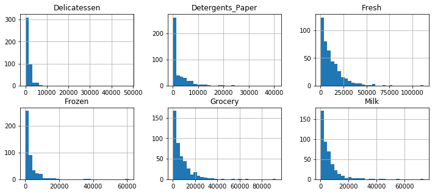

```python
data.hist(bins=30, layout = (2,3), figsize = (12,5))
```

### Implementation: Selecting Samples

To get a better understanding of the customers and how their data will transform through the analysis, it would be best to select a few sample data points and explore them in more detail. In the code below, I look at three costumers whose spending habits vary significantly from each other.

```python
# Select three indices of to sample from the dataset
numbers = np.random.randint(0,439,3)
print(numbers)
indices = numbers
# After several iterations, I settled on indices a sample of 3 costumers that are different
# from each other. Updated indices with chosen costumers.
indices = [30, 402, 200]

# Create a DataFrame of the chosen samples
samples = pd.DataFrame(data.loc[indices], columns = data.keys()).reset_index(drop = True)
print("Chosen samples of wholesale customers dataset:")
display(samples)
```

```
[155 372 346]
Chosen samples of wholesale customers dataset:
```

|  | Fresh | Milk | Grocery | Frozen | Detergents_Paper | Delicatessen |
| --- | --- | --- | --- | --- | --- | --- |
| 0 | 18815 | 3610 | 11107 | 1148 | 2134 | 2963 |
| 1 | 26539 | 4753 | 5091 | 220 | 10 | 340 |
| 2 | 3067 | 13240 | 23127 | 3941 | 9959 | 731 |

### Sample customer preferences

The figure below shows where each of the sampled costumers stands with respect with to the rest in terms of amount spent in each of the categories I am analyzing. The color shade represents the percentile at which the customer (row) stands for that category (column).

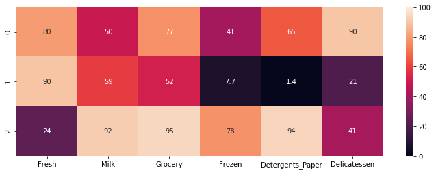

```python
import seaborn as sns

percentiles_data = 100*data.rank(pct=True)
percentiles_samples = percentiles_data.iloc[indices]
mpl.pyplot.figure(figsize=(12, 4))
sns.heatmap(percentiles_samples, annot=True, yticklabels = ["0","1","2"],vmin=0, vmax=100)
```

The three samples vary in where they stand in relation to most values of each category. On a very general especulation, I would guess that:

**0** is likely a family oriented customer who is health conscious. Their spenditure history puts them at the 80th percentile for Fresh, the 75th percentile for Grocery, the 65th percentile for Detergents-paper, and over 90th percentile for Delicatessen, a top spender for all these categories. For Milk and Frozen, consumption is slightly above and below average.

- With this in mind, I hypothesize that this a customer that patronizes supermarkets and retail stores often, including health supermarkets and food stores, as well as co-ops.

**2** looks like a family oriented customer who is not as health-conscious. They are at lower than 25% of consumers on Fresh expenditure and slightly below average on Delicatessen (40-45th percentile), yet spend more than 90% of customers on Milk, more than around 95% of customers on Grocery, more than 75-80% of customers on Frozen, and more than 90-95% of customers on Detergents-paper. Like customer **0**, they seem invested on domestic chores, but unlike them, they spend little on Fresh and Delicaressen.

- This customer could be expected to visit regular supermarkets and retailers, and, when eating out, more likely to visit fast-food venues.

There are many caveats and other potential explanations for the behavior of each customer sampled, and should keep in mind it is just a sample with few variables. For example, buying few products from fresh, as #3, could also be due to being a farmer and sourcing all fresh food needs from their own.

### Feature Relevance

One interesting thought to consider is if one (or more) of the six product categories is actually relevant for understanding customer purchasing. That is to say, is it possible to determine whether customers purchasing some amount of one category of products will necessarily purchase some proportional amount of another category of products? We can make this determination by training a supervised regression learner on a subset of the data with one feature removed, and then score how well that model can predict the removed feature.

In the code block below, I do this for all six features of the dataset.

```python
from sklearn.cross_validation import train_test_split
from sklearn.tree import DecisionTreeRegressor
from sklearn.linear_model import LinearRegression

columns = list(data.columns)

for col in columns:

    # Make a copy of the DataFrame, using the 'drop' function to drop the given feature
    new_data = data.drop([col], axis=1)

    # Split the data into training and testing sets(0.25) using the given feature as the target
    # Set a random state.
    X_train, X_test, y_train, y_test = train_test_split(new_data, data[col],test_size=0.25,random_state=4)

    # Create a decision tree regressor and fit it to the training set
    regressor = DecisionTreeRegressor(random_state=0)
    regressor.fit(X_train, y_train)

    # Create a linear regressor and fit it to the training set
    linear_m = LinearRegression()
    linear_m.fit(X_train, y_train)

    # Report the score of the prediction using the testing set
    score = regressor.score(X_test, y_test)
    score_linear_m = linear_m.score(X_test, y_test)

    print("Decission tree R^2 score when "+ col + " is target: " + str(round(score,2)))
    print("Linear model R^2 score when "+ col + " is target: " + str(round(score_linear_m,2)) + "\n")
```

```
Decission tree R^2 score when Fresh is target: -0.4
Linear model R^2 score when Fresh is target: 0.04

Decission tree R^2 score when Milk is target: 0.58
Linear model R^2 score when Milk is target: 0.65

Decission tree R^2 score when Grocery is target: 0.72
Linear model R^2 score when Grocery is target: 0.93

Decission tree R^2 score when Frozen is target: -0.18
Linear model R^2 score when Frozen is target: 0.13

Decission tree R^2 score when Detergents_Paper is target: 0.69
Linear model R^2 score when Detergents_Paper is target: 0.9

Decission tree R^2 score when Delicatessen is target: -9.5
Linear model R^2 score when Delicatessen is target: -1.06
```

It seems that Milk, Grocery, and Detergents_Paper are the most easily predictable features from spending habits in other categories. Conversely, Fresh, Frozen, and Delicatessen are difficult to predict from the other categories -- with negative R^2, these models fit the data very poorly, worse than a simple average.

A feature which cannot be predicted by other features should not be removed from the dataset for the sake of reducing the dimensionality of our dataset, since its' information content, however useful that might eventually prove to be, is not contained in the rest of the features. On the other hand, a feature that can be predicted from other features would not really give us much additional information and thus, would be a fit candidate for removal, if we ever need it to make the dataset more manageable.

### Visualize Feature Distributions

To get a better understanding of the dataset, we can construct a scatter matrix of each of the six product features present in the data. This will reveal whether there are any visible correlations between any two given variables.

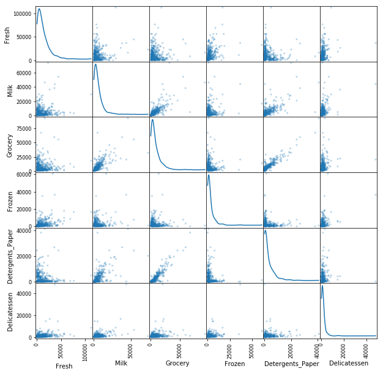

```python
# Produce a scatter matrix for each pair of features in the data
pd.plotting.scatter_matrix(data, alpha = 0.3, figsize = (10,10), diagonal = 'kde');
```

The heatmap below corresponds to the correlation coefficients between each pair of variables.

|  | Fresh | Milk | Grocery | Frozen | Detergents_Paper | Delicatessen |
| --- | --- | --- | --- | --- | --- | --- |
| Fresh | 1.000000 | 0.100510 | -0.011854 | 0.345881 | -0.101953 | 0.244690 |
| Milk | 0.100510 | 1.000000 | 0.728335 | 0.123994 | 0.661816 | 0.406368 |
| Grocery | -0.011854 | 0.728335 | 1.000000 | -0.040193 | 0.924641 | 0.205497 |
| Frozen | 0.345881 | 0.123994 | -0.040193 | 1.000000 | -0.131525 | 0.390947 |
| Detergents_Paper | -0.101953 | 0.661816 | 0.924641 | -0.131525 | 1.000000 | 0.069291 |
| Delicatessen | 0.244690 | 0.406368 | 0.205497 | 0.390947 | 0.069291 | 1.000000 |

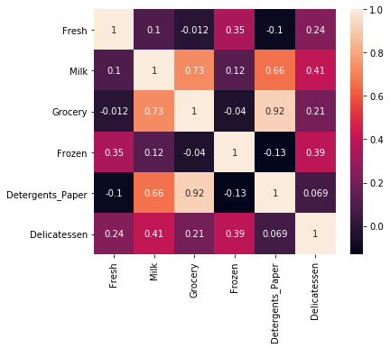

```python
import seaborn as sns
mpl.pyplot.figure(figsize=(6, 5))
sns.heatmap(data.corr(), annot=True)
data.corr()
```

There are three pairs of features that exhibit strong correlation between each other:

```
- Grocery - Detergents_Paper .92
- Milk - Grocery .73
- Milk - Detergents_paper .66
```

The most significant correlation is between Grocery and Detergents_Paper. This implies that both are weakly relevant as they contain approximately the same information, but if we remove one of them, the other becomes strongly relevant. Milk is also correlated with both these features, but the correlation is relatively mild. This mildness of correlation explains, to some extent, the relatively lower R^2-score obtained for Milk in the previous section.

Correlation for other pairs of features is somewhat insignificant, which explains their low/negative R^2-scores in the previous section.

## Data Preprocessing

### Implementation: Feature Scaling

Clustering algorithms discussed in this project work under the assumption that the data features are (roughly) normally distributed. Significant deviation from zero skewness indicates that we must apply some kind of normalisation to make the features normally distributed. In this section I apply the natural logarithm to the values for each feature, in order to achieve an approximately normal distribution for all of them.

Transforming the data by taking the logarithm gives us normal distributions for each variable. The correlations and lack of correlations between variables remain the same, as expected.

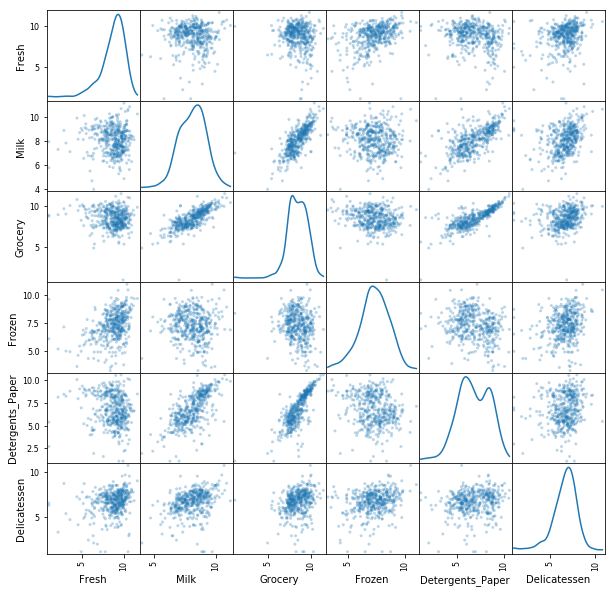

```python
# Scale the data using the natural logarithm
log_data = np.log(data)

# Scale the sample data using the natural logarithm
log_samples = np.log(samples)

# Produce a scatter matrix for each pair of newly-transformed features
pd.plotting.scatter_matrix(log_data, alpha = 0.3, figsize = (10,10), diagonal = 'kde');
```

|  | Fresh | Milk | Grocery | Frozen | Detergents_Paper | Delicatessen |
| --- | --- | --- | --- | --- | --- | --- |
| Fresh | 1.000000 | -0.019834 | -0.132713 | 0.383996 | -0.155871 | 0.255186 |
| Milk | -0.019834 | 1.000000 | 0.758851 | -0.055316 | 0.677942 | 0.337833 |
| Grocery | -0.132713 | 0.758851 | 1.000000 | -0.164524 | 0.796398 | 0.235728 |
| Frozen | 0.383996 | -0.055316 | -0.164524 | 1.000000 | -0.211576 | 0.254718 |
| Detergents_Paper | -0.155871 | 0.677942 | 0.796398 | -0.211576 | 1.000000 | 0.166735 |
| Delicatessen | 0.255186 | 0.337833 | 0.235728 | 0.254718 | 0.166735 | 1.000000 |

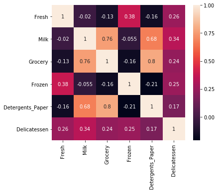

```python
mpl.pyplot.figure(figsize=(6, 5))
sns.heatmap(log_data.corr(), annot=True)
log_data.corr()
```

### Implementation: Outlier Detection

Detecting outliers in the data is extremely important in the data preprocessing step of any analysis. The presence of outliers can often skew results which take into consideration these data points. Here, I we will use [Tukey's Method for identfying outliers](http://datapigtechnologies.com/blog/index.php/highlighting-outliers-in-your-data-with-the-tukey-method/): An *outlier step* is calculated as 1.5 times the interquartile range (IQR). A data point with a feature that is beyond an outlier step outside of the IQR for that feature is considered abnormal.

```python
# Create an array of all outliers
all_outliers = np.array([], dtype='int64')

# For each feature find the data points with extreme high or low values
for feature in log_data.keys():

    # Calculate Q1 (25th percentile of the data) for the given feature
    Q1 = log_data[feature].quantile(q=.25)

    # Calculate Q3 (75th percentile of the data) for the given feature
    Q3 = log_data[feature].quantile(q=.75)

    # Use the interquartile range to calculate an outlier step (1.5 times the interquartile range)
    step = 1.5*(Q3-Q1)

    # Display the outliers
    print("Data points considered outliers for the feature '{}':".format(feature))
    indices = ~((log_data[feature] >= Q1 - step) & (log_data[feature] <= Q3 + step))
    display(log_data[indices])
    outlier_points = log_data[indices]

    # OSelect the indices for data points to remove
    all_outliers = np.append(all_outliers, outlier_points.index.values.astype('int64'))

# Count the unique elements in the all_outliers array
all_outlier, indices = np.unique(all_outliers, return_inverse=True)
counts = np.bincount(indices)

# These are the "outliers" that appeared in several variables
repeated_outliers = all_outlier[counts>1]
print("Repeated outliers: " + str(repeated_outliers))

# Remove the outliers, if any were specified
good_data = log_data.drop(log_data.index[repeated_outliers]).reset_index(drop = True)
```

```
Data points considered outliers for the feature 'Fresh':
```

|  | Fresh | Milk | Grocery | Frozen | Detergents_Paper | Delicatessen |
| --- | --- | --- | --- | --- | --- | --- |
| 65 | 4.442651 | 9.950323 | 10.732651 | 3.583519 | 10.095388 | 7.260523 |
| 66 | 2.197225 | 7.335634 | 8.911530 | 5.164786 | 8.151333 | 3.295837 |
| 81 | 5.389072 | 9.163249 | 9.575192 | 5.645447 | 8.964184 | 5.049856 |
| 95 | 1.098612 | 7.979339 | 8.740657 | 6.086775 | 5.407172 | 6.563856 |
| 96 | 3.135494 | 7.869402 | 9.001839 | 4.976734 | 8.262043 | 5.379897 |
| 128 | 4.941642 | 9.087834 | 8.248791 | 4.955827 | 6.967909 | 1.098612 |
| 171 | 5.298317 | 10.160530 | 9.894245 | 6.478510 | 9.079434 | 8.740337 |
| 193 | 5.192957 | 8.156223 | 9.917982 | 6.865891 | 8.633731 | 6.501290 |
| 218 | 2.890372 | 8.923191 | 9.629380 | 7.158514 | 8.475746 | 8.759669 |
| 304 | 5.081404 | 8.917311 | 10.117510 | 6.424869 | 9.374413 | 7.787382 |
| 305 | 5.493061 | 9.468001 | 9.088399 | 6.683361 | 8.271037 | 5.351858 |
| 338 | 1.098612 | 5.808142 | 8.856661 | 9.655090 | 2.708050 | 6.309918 |
| 353 | 4.762174 | 8.742574 | 9.961898 | 5.429346 | 9.069007 | 7.013016 |
| 355 | 5.247024 | 6.588926 | 7.606885 | 5.501258 | 5.214936 | 4.844187 |
| 357 | 3.610918 | 7.150701 | 10.011086 | 4.919981 | 8.816853 | 4.700480 |
| 412 | 4.574711 | 8.190077 | 9.425452 | 4.584967 | 7.996317 | 4.127134 |

```
Data points considered outliers for the feature 'Milk':
```

|  | Fresh | Milk | Grocery | Frozen | Detergents_Paper | Delicatessen |
| --- | --- | --- | --- | --- | --- | --- |
| 86 | 10.039983 | 11.205013 | 10.377047 | 6.894670 | 9.906981 | 6.805723 |
| 98 | 6.220590 | 4.718499 | 6.656727 | 6.796824 | 4.025352 | 4.882802 |
| 154 | 6.432940 | 4.007333 | 4.919981 | 4.317488 | 1.945910 | 2.079442 |
| 356 | 10.029503 | 4.897840 | 5.384495 | 8.057377 | 2.197225 | 6.306275 |

```
Data points considered outliers for the feature 'Grocery':
```

|  | Fresh | Milk | Grocery | Frozen | Detergents_Paper | Delicatessen |
| --- | --- | --- | --- | --- | --- | --- |
| 75 | 9.923192 | 7.036148 | 1.098612 | 8.390949 | 1.098612 | 6.882437 |
| 154 | 6.432940 | 4.007333 | 4.919981 | 4.317488 | 1.945910 | 2.079442 |

```
Data points considered outliers for the feature 'Frozen':
```

|  | Fresh | Milk | Grocery | Frozen | Detergents_Paper | Delicatessen |
| --- | --- | --- | --- | --- | --- | --- |
| 38 | 8.431853 | 9.663261 | 9.723703 | 3.496508 | 8.847360 | 6.070738 |
| 57 | 8.597297 | 9.203618 | 9.257892 | 3.637586 | 8.932213 | 7.156177 |
| 65 | 4.442651 | 9.950323 | 10.732651 | 3.583519 | 10.095388 | 7.260523 |
| 145 | 10.000569 | 9.034080 | 10.457143 | 3.737670 | 9.440738 | 8.396155 |
| 175 | 7.759187 | 8.967632 | 9.382106 | 3.951244 | 8.341887 | 7.436617 |
| 264 | 6.978214 | 9.177714 | 9.645041 | 4.110874 | 8.696176 | 7.142827 |
| 325 | 10.395650 | 9.728181 | 9.519735 | 11.016479 | 7.148346 | 8.632128 |
| 420 | 8.402007 | 8.569026 | 9.490015 | 3.218876 | 8.827321 | 7.239215 |
| 429 | 9.060331 | 7.467371 | 8.183118 | 3.850148 | 4.430817 | 7.824446 |
| 439 | 7.932721 | 7.437206 | 7.828038 | 4.174387 | 6.167516 | 3.951244 |

```
Data points considered outliers for the feature 'Detergents_Paper':
```

|  | Fresh | Milk | Grocery | Frozen | Detergents_Paper | Delicatessen |
| --- | --- | --- | --- | --- | --- | --- |
| 75 | 9.923192 | 7.036148 | 1.098612 | 8.390949 | 1.098612 | 6.882437 |
| 161 | 9.428190 | 6.291569 | 5.645447 | 6.995766 | 1.098612 | 7.711101 |

```
Data points considered outliers for the feature 'Delicatessen':
```

|  | Fresh | Milk | Grocery | Frozen | Detergents_Paper | Delicatessen |
| --- | --- | --- | --- | --- | --- | --- |
| 66 | 2.197225 | 7.335634 | 8.911530 | 5.164786 | 8.151333 | 3.295837 |
| 109 | 7.248504 | 9.724899 | 10.274568 | 6.511745 | 6.728629 | 1.098612 |
| 128 | 4.941642 | 9.087834 | 8.248791 | 4.955827 | 6.967909 | 1.098612 |
| 137 | 8.034955 | 8.997147 | 9.021840 | 6.493754 | 6.580639 | 3.583519 |
| 142 | 10.519646 | 8.875147 | 9.018332 | 8.004700 | 2.995732 | 1.098612 |
| 154 | 6.432940 | 4.007333 | 4.919981 | 4.317488 | 1.945910 | 2.079442 |
| 183 | 10.514529 | 10.690808 | 9.911952 | 10.505999 | 5.476464 | 10.777768 |
| 184 | 5.789960 | 6.822197 | 8.457443 | 4.304065 | 5.811141 | 2.397895 |
| 187 | 7.798933 | 8.987447 | 9.192075 | 8.743372 | 8.148735 | 1.098612 |
| 203 | 6.368187 | 6.529419 | 7.703459 | 6.150603 | 6.860664 | 2.890372 |
| 233 | 6.871091 | 8.513988 | 8.106515 | 6.842683 | 6.013715 | 1.945910 |
| 285 | 10.602965 | 6.461468 | 8.188689 | 6.948897 | 6.077642 | 2.890372 |
| 289 | 10.663966 | 5.655992 | 6.154858 | 7.235619 | 3.465736 | 3.091042 |
| 343 | 7.431892 | 8.848509 | 10.177932 | 7.283448 | 9.646593 | 3.610918 |

```
Repeated outliers: [ 65  66  75 128 154]
```

```python
print("Outlier percentage of total data: " + str(round(all_outliers.shape[0]*100/log_data.shape[0],2)) + "%")
print("Repeated outliers percentage of total data: " + str(round(repeated_outliers.shape[0]*100/log_data.shape[0],2)) + "%")
```

```
Outlier percentage of total data: 10.91%
Repeated outliers percentage of total data: 1.14%
```

By looking at this procedure, ~11% of the original data is deemed "outliers". However, this being such a large proportion of the data, it is unadvisable to remove it without particularly strong reasons. Doing so would impact the results of the algorithm we use.

A stronger case can be made for datapoints that are outliers in more than one feature. They represent only ~1% of the dataset, and removing them could actually improve the performance of the chosen model.

## Feature Transformation

In this section you will use principal component analysis (PCA) to draw conclusions about the underlying structure of the wholesale customer data. Since using PCA on a dataset calculates the dimensions which best maximize variance, we will find which compound combinations of features best describe customers.

### Implementation: PCA

Now that the data has been scaled to a more normal distribution and has had any necessary outliers removed, we can apply PCA to the `good_data` to discover which dimensions about the data best maximize the variance of features involved. In addition to finding these dimensions, PCA will also report the *explained variance ratio* of each dimension — how much variance within the data is explained by that dimension alone. A component (dimension) from PCA can be considered a new "feature" of the space, however it is a composition of the original features present in the data.

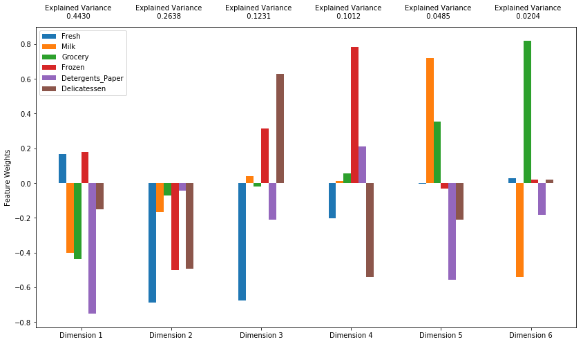

```python
from sklearn.decomposition import PCA

# Apply PCA by fitting the good data with the same number of dimensions as features
pca = PCA(n_components=good_data.shape[1])
pca.fit(good_data)

# Transform log_samples using the PCA fit above
pca_samples = pca.transform(log_samples)

# Generate PCA results plot
pca_results = vs.pca_results(good_data, pca)
```

```python
pca_results
```

|  | Explained Variance | Fresh | Milk | Grocery | Frozen | Detergents_Paper | Delicatessen |
| --- | --- | --- | --- | --- | --- | --- | --- |
| Dimension 1 | 0.4430 | 0.1675 | -0.4014 | -0.4381 | 0.1782 | -0.7514 | -0.1499 |
| Dimension 2 | 0.2638 | -0.6859 | -0.1672 | -0.0707 | -0.5005 | -0.0424 | -0.4941 |
| Dimension 3 | 0.1231 | -0.6774 | 0.0402 | -0.0195 | 0.3150 | -0.2117 | 0.6286 |
| Dimension 4 | 0.1012 | -0.2043 | 0.0128 | 0.0557 | 0.7854 | 0.2096 | -0.5423 |
| Dimension 5 | 0.0485 | -0.0026 | 0.7192 | 0.3554 | -0.0331 | -0.5582 | -0.2092 |
| Dimension 6 | 0.0204 | 0.0292 | -0.5402 | 0.8205 | 0.0205 | -0.1824 | 0.0197 |

```python
print(pca_results['Explained Variance'].cumsum())
```

```
Dimension 1    0.4430
Dimension 2    0.7068
Dimension 3    0.8299
Dimension 4    0.9311
Dimension 5    0.9796
Dimension 6    1.0000
Name: Explained Variance, dtype: float64
```

It is important to notice that by adding the first four components, they **together** account form 93% of the variance. Importantly, just the first two components get us well over half of the variance in the dataset, 70%.

The high *absolute* values of certain features in each component speak of the relative importance of the given feature for the component, especially relevant for the present objective of separating costumers in different categories.

### Observation

The code below to displays how the log-transformed sample data has changed after having a PCA transformation applied to it in six dimensions. The numerical value for the first four dimensions of the sample points shows that this is consistent with the initial interpretation of the sample points.

```python
# Display sample log-data after having a PCA transformation applied
display(pd.DataFrame(np.round(pca_samples, 4), columns = pca_results.index.values))
```

|  | Dimension 1 | Dimension 2 | Dimension 3 | Dimension 4 | Dimension 5 | Dimension 6 |
| --- | --- | --- | --- | --- | --- | --- |
| 0 | -1.1156 | -1.3483 | -0.1973 | -0.9135 | -0.4000 | 0.5608 |
| 1 | 3.2335 | 0.5493 | -1.1499 | -2.2714 | 3.0208 | 0.6836 |
| 2 | -2.9903 | -0.3645 | 0.2521 | 1.5653 | 0.1922 | 0.1244 |

### Implementation: Dimensionality Reduction

When using principal component analysis, one of the main goals is to reduce the dimensionality of the data — in effect, reducing the complexity of the problem. Dimensionality reduction comes at a cost: Fewer dimensions used implies less of the total variance in the data is being explained. Because of this, the *cumulative explained variance ratio* is extremely important for knowing how many dimensions are necessary for the problem. Additionally, if a signifiant amount of variance is explained by only two or three dimensions, the reduced data can be visualized afterwards.

```python
# Apply PCA by fitting the good data with only two dimensions
pca = PCA(n_components = 2)
pca.fit(good_data)

# Transform the good data using the PCA fit above
reduced_data = pca.transform(good_data)

# Transform log_samples using the PCA fit above
pca_samples = pca.transform(log_samples)

# Create a DataFrame for the reduced data
reduced_data = pd.DataFrame(reduced_data, columns = ['Dimension 1', 'Dimension 2'])
```

### Observation

The code below shows how the log-transformed sample data has changed after having a PCA transformation applied to it using only two dimensions. The values for the first two dimensions remain unchanged when compared to a PCA transformation in six dimensions.

```python
# Display sample log-data after applying PCA transformation in two dimensions
display(pd.DataFrame(np.round(pca_samples, 4), columns = ['Dimension 1', 'Dimension 2']))
```

|  | Dimension 1 | Dimension 2 |
| --- | --- | --- |
| 0 | -1.1156 | -1.3483 |
| 1 | 3.2335 | 0.5493 |
| 2 | -2.9903 | -0.3645 |

## Visualizing a Biplot

A biplot is a scatterplot where each data point is represented by its scores along the principal components. The axes are the principal components (in this case `Dimension 1` and `Dimension 2`). In addition, the biplot shows the projection of the original features along the components. A biplot can help us interpret the reduced dimensions of the data, and discover relationships between the principal components and original features.

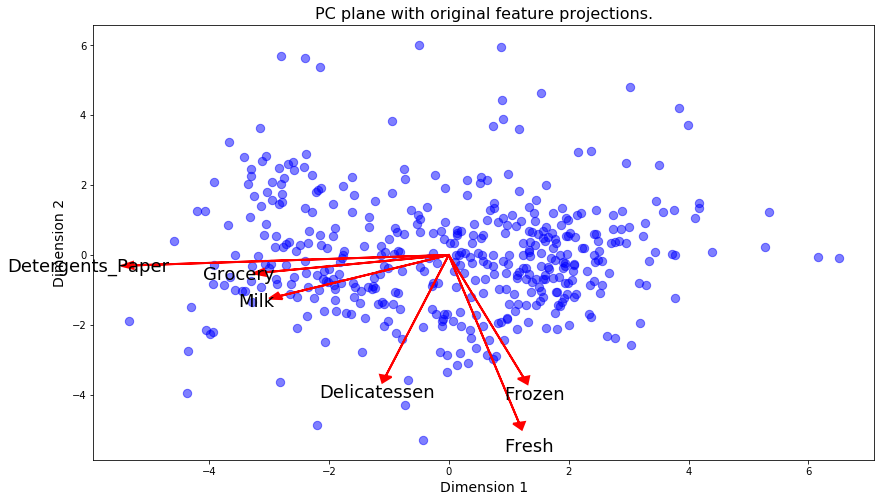

```python
# Create a biplot
vs.biplot(good_data, reduced_data, pca)
```

### Observation

From the biplot we see that Detergents_paper, Grocery, and Milk are the original features most strongly correlated with the first component. For the second component, the most relevant original features are Fresg, Frozen, and Delicatessen. These observations agree with the bar plots of each component in an earlier figure.

## Clustering

In this section, I will use the first two principal components to attempt to cluster the customers from the dataset into relevant groups according to their spending habits. The two clustering algorihtms I consider are K-Means clustering and Gaussian Mixture Models clustering.

K-Means clustering is fast and can produce tight clusters, it is great for cases in which the underlying clusters are neatly separated from each other, tightly wound together, and spherical along all dimensions. However, for cases in which members of a cluster do not conform to a circular or spherical shape and consequently have varying distances to its center, K-means fails, since it relies on distance-to-centroid as definition for clustering. Furthermore, it is very sensitive to initialization values.

Gaussian Mixture Model clustering, on the other hand, has a slower convergence rate, but it has several advantages. This algorithm allows for greater shape flexibility, including the possibility that a cluster contains another clustering within it. And the soft-clustering approach allows for membership of datapoints to several clusters.

For the present dataset, a soft-clustering approach such as what is afforded with Gaussian Mixture Models makes more sense, especially considering that there are no visually separable clusters in the biplot. The dataset is quite small and scalability is not an issue.

For large datasets, an alternative strategy could be to use the faster K-Means for preliminary analysis, and if upon revision we determine that the results could be significantly improved, use Gaussian Mixture Model in the next step while using the cluster assignments and centres obtained from K-Means as the initialisation for Gaussian Mixture Model.

### Implementation: determining optimal number of clusters

Depending on the problem, the number of clusters expected to be in the data may already be known. When the number of clusters is not known *a priori*, there is no guarantee that a given number of clusters best segments the data, since it is unclear what structure exists in the data — if any. However, we can quantify the "goodness" of a clustering by calculating each data point's *silhouette coefficient*. The [silhouette coefficient](http://scikit-learn.org/stable/modules/generated/sklearn.metrics.silhouette_score.html) for a data point measures how similar it is to its assigned cluster from -1 (dissimilar) to 1 (similar). Calculating the *mean* silhouette coefficient provides for a simple scoring method of a given clustering.

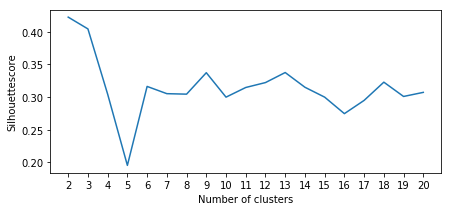

```
Highest score: 0.42
```

```python
from sklearn.mixture import GaussianMixture
from sklearn.metrics import silhouette_score

clusters = np.linspace(2,20,19, dtype=int)
scores = list()

for cluster_number in clusters:

    # Apply your clustering algorithm of choice to the reduced data
    clusterer = GaussianMixture(n_components= cluster_number)
    clusterer.fit(reduced_data)

    # Predict the cluster for each data point
    preds = clusterer.predict(reduced_data)

    # Find the cluster centers
    centers = clusterer.means_

    # Calculate the mean silhouette coefficient for the number of clusters chosen
    score = silhouette_score(reduced_data, preds)
    scores.append(score)

    #print("Cluster number: " + str(cluster_number) + "  Score: " + str(round(score,2)))

import matplotlib.pyplot as plt
plt.figure(figsize=(7,3))
plt.plot(clusters, scores)
plt.ylabel('Silhouettescore')
plt.xlabel('Number of clusters')
plt.xticks(clusters)
plt.show()
print("Highest score: " + str(round(max(scores),2)))
```

As the figure above shows, the highest silhouette score, 0.42, is for when we use **two** clusters.

### Implementation: clustering algorithm

Once the optimal number of clusters has been chosen using the scoring metric above, we can initialize and fit the model.

```python
# Initialize model with optimal number of clusters
clusterer = GaussianMixture(n_components= 2)
clusterer.fit(reduced_data)

#Predict the cluster for each data point
preds = clusterer.predict(reduced_data)

#Find the cluster centers
centers = clusterer.means_
```

#### Function to visualize contours of predicted TWO clusters

The following function allows to visualize the contours of the predicted two clusters, overlaid over the colored scatterplots.

```python
import matplotlib.mlab as mlab

# Reset preds to outcome from a GMM model of 2 clusters
clusterer = GaussianMixture(n_components= 2)
clusterer.fit(reduced_data)
preds = clusterer.predict(reduced_data)

def draw_contours():
    # --- Contours of each cluster ---
    # Subset of one cluster
    ones = reduced_data[preds.astype(bool)]

    # Subset of another cluster
    nopreds = abs(preds-1)
    zeros = reduced_data[nopreds.astype(bool)]

    # Prepare grid
    x = np.arange(-7.0, 7.0,0.025)
    y = np.arange(-7.0, 7.0,0.025)
    X, Y = np.meshgrid(x, y)

    for subtable in [zeros, ones]:

        tab = subtable

        a = np.var(tab["Dimension 1"])
        b = np.var(tab["Dimension 2"])
        c = np.mean(tab["Dimension 1"])
        d = np.mean(tab["Dimension 2"])
        Z_0 = mlab.bivariate_normal(X, Y, a,b,c,d)

        plt.contour(X, Y, Z_0)
        plt.scatter(tab["Dimension 1"], tab["Dimension 2"], 5)
        plt.xlabel("Dimension 1")
        plt.ylabel("Dimension 2")
```

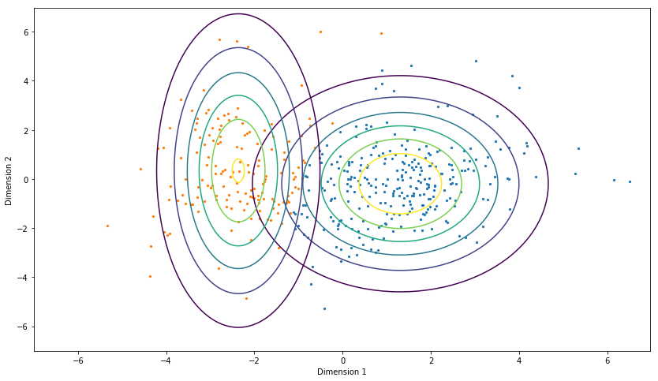

```python
draw_contours()
```

### Observation

From the figure above we can see the two customer clusters along with their area of overlap. This is an advantage of using a Gaussian Mixture Model, for the possibility of soft clustering datapoints that could belong to more than one cluster.

The superimposed biplot below illustrates the mapping of the real world variables onto the principal components. This aids in the interpretation of the clustering in terms of the original features of the dataset.

The two clusters are divided mainly along the direction of tendency to buy Detergents_paper, Grocery, and Milk. This would indicate a split between customers that are more involved in household maintenance (cleaning and cooking), and customers who are not. The first group would be more commonly expected at supermarkets, while the second group is more likely at restaurants.

Including other principal components could potentially help fine tune the overlapping areas between dimension 1 and dimension 2.

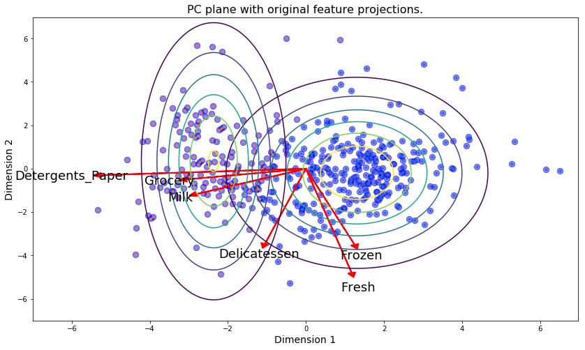

```python
vs.biplot(good_data, reduced_data, pca)
draw_contours()
plt.show()
```

### Implementation: Data Recovery

Each cluster present in the visualization above has a central point. These centers (or means) are not specifically data points from the data, but rather the *averages* of all the data points predicted in the respective clusters. For the problem of creating customer segments, a cluster's center point corresponds to *the average customer of that segment*. Since the data is currently reduced in dimension and scaled by a logarithm, we can recover the representative customer spending from these data points by applying the inverse transformations.

```python
# Inverse transform the centers -- to return to original number of variables
log_centers = pca.inverse_transform(centers)

# Exponentiate the centers -- to descale from log to original values
true_centers = np.exp(log_centers)

# Display the true centers
segments = ['Segment {}'.format(i) for i in range(0,len(centers))]
true_centers = pd.DataFrame(np.round(true_centers), columns = data.keys())
true_centers.index = segments
display(true_centers)
```

|  | Fresh | Milk | Grocery | Frozen | Detergents_Paper | Delicatessen |
| --- | --- | --- | --- | --- | --- | --- |
| Segment 0 | 3552.0 | 7837.0 | 12219.0 | 870.0 | 4696.0 | 962.0 |
| Segment 1 | 8953.0 | 2114.0 | 2765.0 | 2075.0 | 353.0 | 732.0 |

The table above displays the actual values in monetary units for each of the original, real world variables.

### Examining predictions the 3 sample customers chosen in terms of their assigned clusters

```python
display(samples)

# Predict the cluster for each transformed sample data point
sample_preds = clusterer.predict(pca_samples)

# Display the predictions
for i, pred in enumerate(sample_preds):
    print("Sample point", i, "predicted to be in Cluster", pred)
```

|  | Fresh | Milk | Grocery | Frozen | Detergents_Paper | Delicatessen |
| --- | --- | --- | --- | --- | --- | --- |
| 0 | 18815 | 3610 | 11107 | 1148 | 2134 | 2963 |
| 1 | 26539 | 4753 | 5091 | 220 | 10 | 340 |
| 2 | 3067 | 13240 | 23127 | 3941 | 9959 | 731 |

```
Sample point 0 predicted to be in Cluster 0
Sample point 1 predicted to be in Cluster 0
Sample point 2 predicted to be in Cluster 1
```

Sample point 1 spends large amounts on Fresh abd very little on Detergents_paper and Grocery (by comparison to the others). This is enough to offset that this particular customer does not spend much on Delicatessen.

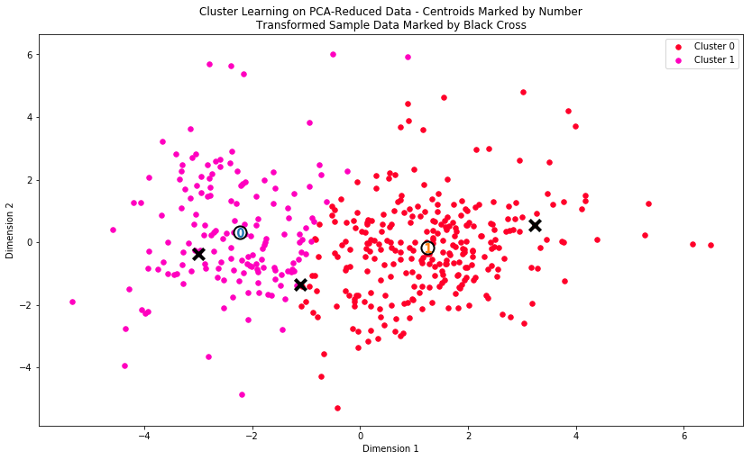

```python
# Display the results of the clustering from implementation
vs.cluster_results(reduced_data, preds, centers, pca_samples)
```

## Conclusion and suggestions

This final section presents two ways in which the clustered data could be used.

First, we will consider how the different groups of customers, the *customer segments*, may be affected differently by a specific delivery scheme.

Next, we will consider how giving a label to each customer (which *segment* that customer belongs to) can provide for additional features about the customer data.

### Case 1

Companies will often run [A/B tests](https://en.wikipedia.org/wiki/A/B_testing) when making small changes to their products or services to determine whether making that change will affect its customers positively or negatively. The wholesale distributor is considering changing its delivery service from currently 5 days a week to 3 days a week. However, the distributor will only make this change in delivery service for customers that react positively.

- How can the wholesale distributor use the customer segments to determine which customers, if any, would react positively to the change in delivery service?*

### Case 2

If the wholesale distributor acquires new customers and each provides estimates for anticipated annual spending of each product category, knowing these estimates, the wholesale distributor can classify each new customer to a *customer segment* to determine the most appropriate delivery service.

- How could this be done? That is, how could the wholesale distributor label the new customers using only their estimated product spending and the **customer segment** data?

The present project has found a systematic grouping within the existing pool of customers. They can be divided into belonging to cluster 0 or cluster 1 type of customer -- the dependent variable.

With this existing data which has now been labeled in a manner that is useful to the wholesale seller, a supervised learning algorithm could be trained and used to make predictions about what type the new customers belong to. I believe that a classifier decission tree, multivariate regression, or a neural network, would be useful supervised algorithms for this purpose.